# Questionnaire Report for rougheye rockfish

(MERA version 4.1.6)

robertolicandeo@gmail.com

2019-04-30

# 1 About this document

This is a prototype of an automatic report that documents how the user specified the operating model and their various justifications.

# 2 Introduction

1. Describe the history and current status of the fishery, including fleets, sectors, vessel types and practices/gear by vessel type, landing ports, economics/markets, whether targeted/bycatch, other stocks caught in the fishery.

This fishery comprises two species, Rougheye Rockfish (Sebastes aleutianus) and Blackspotted Rockfish (Sebastes melanostictus). it is not possible to separate these species in the fishing operations. The only known method to distinguish the two species accurately is through DNA analysis. The recently discovered existence of two species within what was formerly known as Rougheye Rockfish, and the resultant lack of biological knowledge of the Rougheye/Blackspotted Rockfish complex could constitute a threat in itself, due to the increased risk of loss of unrecognized biological diversity (Fisheries and Oceans Canada. 2012). The Rougheye/Blackspotted Rockfish complex and Longspine Thornyhead are harvested by the commercial groundfish fishery in British Columbia. This fishery is managed by Total Allowable Catches (TACs), Individual Vessel Quotas (IVQs), as well as 100% at-sea and dockside monitoring programs. The Rougheye/Blackspotted Rockfish complex and Longspine Thornyhead are listed under the Species at Risk Act as ‘special concern’ meaning that they are considered wildlife species that could become threatened or endangered because of a combination of biological characteristics and identified threats. COSEWIC Status: Special Concern.

2. Describe the stock’s ecosystem functions, dependencies, and habitat types. The highest densities of the Rougheye/Blackspotted Rockfish complex occurs on the sea floor with soft substrates, in areas with frequent boulders and on slopes greater than 20°. The association with soft substrate may be attritutable to preferred prey items like pandalid shrimps (stomach content analyses, Yang and Nelson 2000). The Rougheye/Blackspotted Rockfish complex co-occurs with numerous commercially harvested species, including Pacific ocean perch (Sebastes alutus) and Arrowtooth Flounder (Atheresthes stomias) in the groundfish trawl fishery, and Redbanded Rockfish (S. babcocki) and Shortraker Rockfish (S. borealis) in the groundfish hook and line fisheries (Figure 5). Other than competition for food resources with these species, there is no current information on interactions that might limit the survival of the Rougheye/Blackspotted Rockfish complex. (Fisheries and Oceans Canada. 2012, p16). Predators likely include Pacific Halibut (Hippoglossus stenolepis), Pacific Cod (Gadus macrocephalus), and Sablefish (Amoplopoma fimbria) (Shotwell et al. 2009).
3. Provide all relevant reference materials, such as assessments, research, and other analysis.

In Canadian waters abundance information is derived from surveys and from the commercial fishery that has maintained a relatively constant reported catch of between 1000 and 2000 tonnes annually over the last two decades. Abundance indices and biomass estimates are uncertain, compromised by short time series and survey techniques not always appropriate for the species. No strong abundance trends are observed in the available indices. There is evidence of truncation of the age distribution over the last decade, suggesting that mortality from all sources may have doubled (4.5% y -1 to 9.1%y -1 ). Long-lived, low-fecundity Sebastes species are particularly susceptible to population collapse, and recovery may be compromised when the age- and size-distribution is truncated (i.e., when the number of spawners declines) through fishing (Fisheries and Oceans Canada. 2012, p8). The complex co-occurs with numerous commercially harvested species, including Arrowtooth Flounder (Atheresthes stomias), Pacific Ocean Perch (Sebastes alutus), Dover Sole (Microstomus pacificus), Petrale Sole (Eopsetta jordani), Shortspine Thornyhead (Sebastolobus alascanus), and Sablefish (Anoplopoma fimbria) (Fisheries and Oceans Canada. 2012, p15). Given the benthic nature of the complex, it is targeted by the commercial groundfish trawl and hook and line fleets. The commercial harvest for these species (Tables 2 and 3) are managed by DFO. The DFO establishes a commercial Total Allowable Catch (TAC) for the Rougheye/Blackspotted Rockfish Complex and Longspine Thornyhead, which sets the maximum amount of harvest permitted to be taken, as well as the area they may be taken from, in a given fishing season. These TACs are changed over time as new peer-reviewed science information becomes available. The coastwide TAC is currently 1,140 tonnes for the Rougheye/Blackspotted Rockfish complex and 425 tonnes for Longspine Thornyhead. In addition, these fisheries are managed using individual transferable quotas (ITQs), which allows the trading of quota within and between the various commercial groundfish fishing sectors. Furthermore, the commercial fishing sector is subject to a comprehensive 100% at-sea and dockside monitoring program (Fisheries and Oceans Canada. 2012, p23). Considerable additional scientific work will be required to describe the relative abundance of the two species in Canadian waters, their distribution, and the impacts of fisheries (and potentially other threats) on each. nCurrently, DFO has little information on Rougheye Rockfish and Blackspotted Rockfish (S. melanostictus) in Canadian Pacific waters. Based on the diagnostics reported in the literature, DFO Science surveys initially tried to distinguish these species based on the presence and/or absence of discrete spots on the dorsal fin, but abandoned this practice due to high pattern variability. Difficulty in distinguishing Rougheye and Blackspotted Rockfish presents a challenge to the management of both species. In the absence of sufficient biological information on either species, the two can only be managed as a species complex, until sufficient research identifies a method to manage them separately between the two species. The main threat to the Rougheye/Blackspotted Rockfish complex and Longspine Thornyhead is population decline as a result of direct and indirect biological resource use. Although there is a lack of knowledge on the relative abundance and distribution of Rougheye and Blackspotted Rockfish, management actions that may reduce the risk of population-level threats should be considered. Stock status is currently based on relative abundance indices from DFO Science surveys or commercial CPUE to monitor trends in populations (see Section 2.3.3). The current management regime (outlined in Section 1.8) regulates the commercial Rougheye/Blackspotted Rockfish complex and Longspine Thornyhead fisheries through the use of ITQs, trip limits and a comprehensive catch monitoring program. Management tools that are available to DFO fishery managers include the use of area and time closures and adjusting species’ TAC limits. In addition, fishery management objectives are reviewed every season and included in annual IFMPs, which are used to guide the management of the fishery (see Sections 2.3.3 and 4). Since the COSEWIC Stock Status Report for the Rougheye/Blackspotted Rockfish complex was published in 2007, DFO Science has added new index points to the various DFO Science research survey series. DFO Science will continue to gather Rougheye Rockfish and Blackspotted Rockfish data from the various DFO Science surveys to monitor and assess population trends and abundance. In addition, when sufficient genetic samples of the rockfish complex are gathered, DFO Science should be able to determine proportions of Rougheye Rockfish and Blackspotted Rockfish in Canadian Pacific waters. These ratios might also be useful in disaggregating historic catches where only Rougheye Rockfish were reported. For the Rougheye/Blackspotted Rockfish complex, ageing otoliths via break-and-burn results in a high degree of imprecision (± 5 y, Shayne MacLellan, DFO, pers. comm., supervisor of the PBS fish ageing laboratory, 2010). Ageing error won’t disable an age structured model, but it probably increases the uncertainty of the results.

Abundance indices can be constructed from numerous data sources – Hecate Strait (HS) assemblage survey, Queen Charlotte Sound (QCS) synoptic survey, QCS shrimp survey, west coast of Vancouver Island (WCVI) shrimp survey, and the observed commercial trawl fishery. Most of these are unsuitable as abundance indices due to high index CVs for this species. The most appropriate surveys for abundance indices in future will be the synoptic groundfish surveys started in 2003 (Stanley et al. 2004). Currently these are running in QCS and WCVI. As the density of rougheye rockfish is highest off the west coast of the Queen Charlotte Islands (WQCI), a similar synoptic survey is needed in this region (Haigh et al., 2005, p1). While survey data are generally considered the most reliable method to use for monitoring demersal marine species, the large error bars in all these surveys indicate that estimated trends are highly uncertain and should probably not be used.

Commercial Groundfish Integrated Fisheries Management Plan (IFMP)

# 3 Fishery Characteristics

## 3.1 Longevity

| Answered |
| --- |
| Very short-lived (5 < maximum age < 7) |
| Short-lived (7 < maximum age < 10) |
| Moderate life span (10 < maximum age < 20) |
| Moderately long-lived (20 < maximum age < 40) |
| Long-lived (40 < maximum age < 80) |
| Very long-lived (80 < maximum age < 160) |

Justification

Fig 3 (see Haigh et al 2005, p10). McDermott (1994) estimated the natural mortality rate M to be 0.030-0.039, using the gonad somatic index (GSI) model of Gunderson and Dygert (1988), modified to incorporate updated information for Pacific cod and walleye pollock:M = 0.00876 +1.697 GSI where GSI = ratio of gonad weight to somatic body weight (see Haigh et al 2005, p11). Generation time is roughly 48 years.

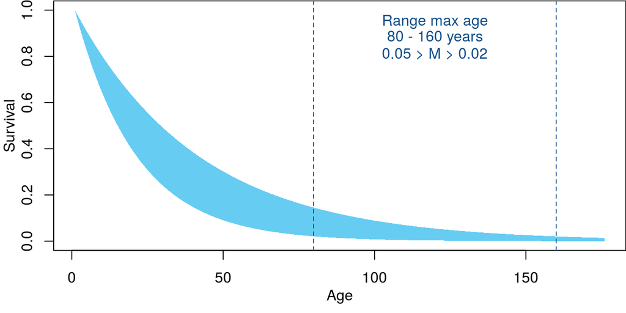

## 3.2 Stock depletion

| Answered |
| --- |
| Crashed (D < 0.05) |
| Very depleted (0.05 < D < 0.1) |
| Depleted (0.1 < D < 0.15) |
| Moderately depleted (0.15 < D < 0.3) |
| Healthy (0.3 < D < 0.5) |
| Underexploited (0.5 < D) |

Justification

Survey indices of abundance are currently not useful for assessing rougheye rockfish population trends. The Hecate Strait assemblage, WCVI shrimp trawl, and NMFS triennial surveys are too shallow. The QCS shrimp survey, while showing an increasing abundance trend, is too limited in areal extent. The QCS synoptic survey, which will become the most reliable, currently has too few data points. The commercial trawl CPUE indices show a slightly increasing trend in 3CD and essentially flat trends in 5AB and 5E (see Haigh et al 2005, Abstract). Catches (Trawl) relatively stable since 1996 (see Table 2, e Haigh et al 2005)

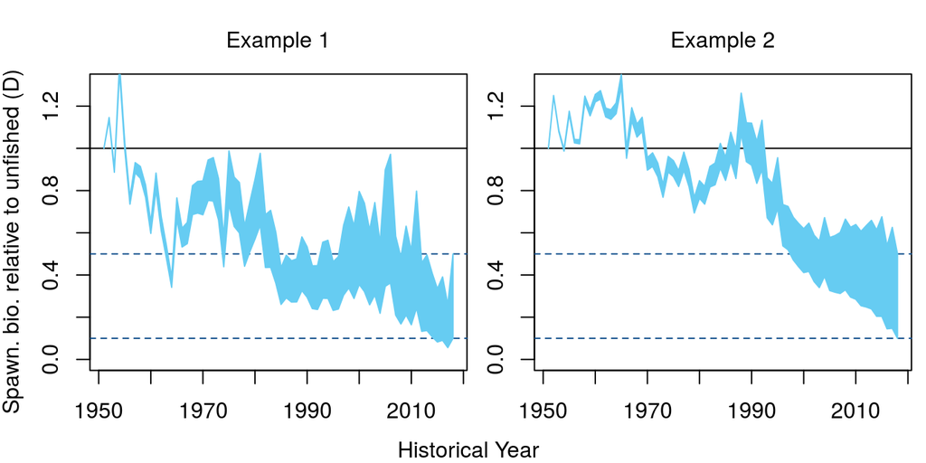

## 3.3 Resilence

| Answered |
| --- |
| Not resilient (steepness < 0.3) |
| Low resilience (0.3 < steepness < 0.5) |
| Moderate resilence (0.5 < steepness < 0.7) |
| Resilient (0.7 < steepness < 0.9) |
| Very Resilient (0.9 < steepness) |

[output not shown]

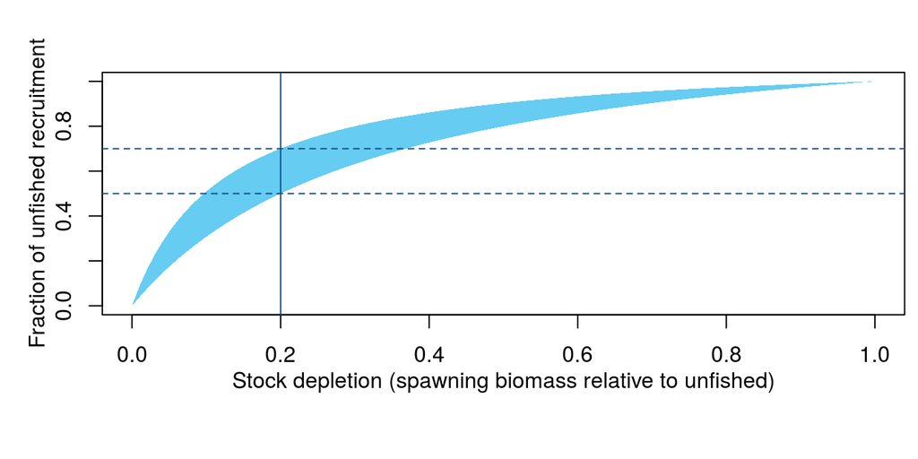

## 3.4 Historical effort pattern

| Answered |
| --- |
| Stable |
| Two-phase |
| Boom-bust |
| Gradual increases |
| Stable, recent increases |
| Stable, recent declines |

| Justification |
| --- |
| mimics catches (Table 2). Surveys with no particular trend during the last years. Same for cpue (see Fig 40, Haigh et al 2005). |

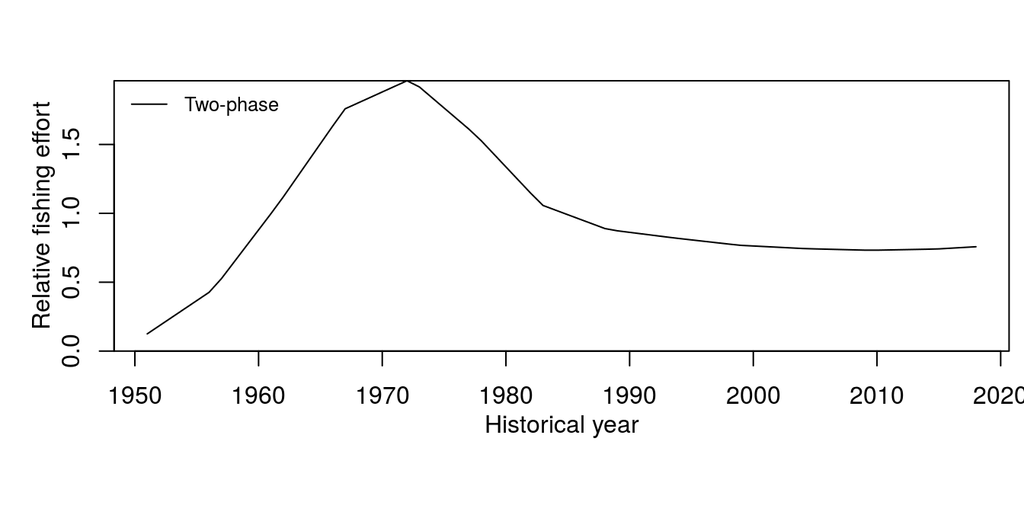

## 3.5 Inter-annual variability in historical effort

| Answered |
| --- |
| Not variable (less than 20% inter-annual change (IAC)) |
| Variable (maximum IAC between 20% to 50%) |
| Highly variable (maximum IAC between 50% and 100%) |

Justification

Survey indices of abundance are currently not useful for assessing rougheye rockfish population trends. The Hecate Strait assemblage, WCVI shrimp trawl, and NMFS triennial surveys are too shallow. The QCS shrimp survey, while showing an increasing abundance trend, is too limited in areal extent. The QCS synoptic survey, which will become the most reliable, currently has too few data points. The commercial trawl CPUE indices show a slightly increasing trend in 3CD and essentially flat trends in 5AB and 5E (see Haigh et al 2005, Abstract). Catches (Trawl) relatively stable since 1996 (see Table 2, e Haigh et al 2005)

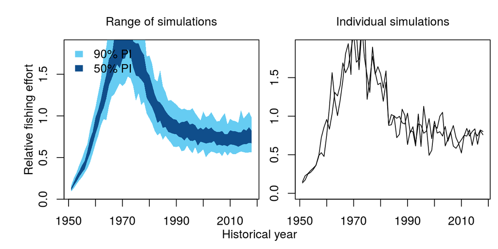

## 3.6 Historical fishing efficiency changes

| Answered |
| --- |
| Declining by 2-3% pa (halves every 25-35 years) |
| Declining by 1-2% pa (halves every 35-70 years) |
| Stable -1% to 1% pa (may halve/double every 70 years) |
| Increasing by 1-2% pa (doubles every 35-70 years) |
| Increasing by 2-3% pa (doubles every 25-35 years) |

Justification

Standardized cpue don’t show a particular trend (see fig 40). The selected lognormal model shows a possible increasing trend since 1999–2000, but this is mainly due to an upturn in the last fishing year (Figure 26 and Figure 27; Table 31). Comparison of CPUE trend lines: Each of the three areas analysed has had two different types of CPUE analysis applied to it: one looking at only non-zero catches (lognormal GLM) and the other looking at the change in the proportion of successful catches (binomial GLM). A comparison of the three areas for each type of GLM analysis shows that there are similarities between series across areas (Figure 40). The data suggest that the WQCI fishery is a target fishery for this species while the species mainly shows up as a bycatch in the other two areas, perhaps indicating that the non-zero catch series may be tracking different aspects of the abundance of this species in each area.

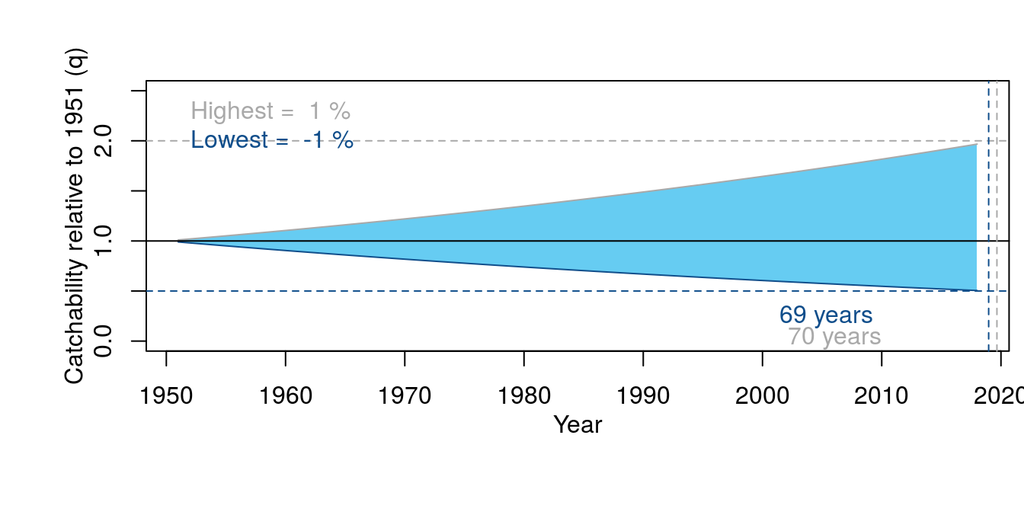

## 3.7 Future fishing efficiency changes

| Answered |
| --- |
| Declining by 2-3% pa (halves every 25-35 years) |
| Declining by 1-2% pa (halves every 35-70 years) |
| Stable -1% to 1% pa (may halve/double every 70 years) |
| Increasing by 1-2% pa (doubles every 35-70 years) |
| Increasing by 2-3% pa (doubles every 25-35 years) |

| Justification |
| --- |
| No justification was provided |

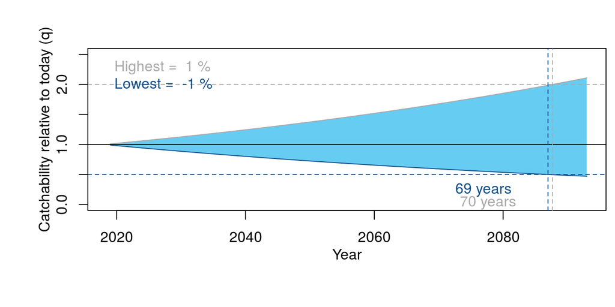

## 3.8 Length at maturity

| Answered |
| --- |
| Very small (0.4 < LM < 0.5) |
| Small (0.5 < LM < 0.6) |
| Moderate (0.6 < LM < 0.7) |
| Moderate to large (0.7 < LM < 0.8) |
| Large (0.8 < LM < 0.9) |

[output not shown]

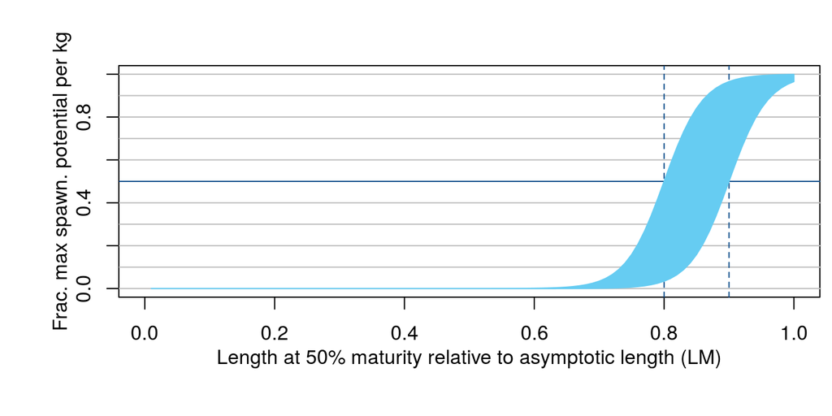

## 3.9 Selectivity of small fish

| Answered |
| --- |
| Very small (0.1 < S < 0.2) |
| Small (0.2 < S < 0.4) |
| Half asymptotic length (0.4 < S < 0.6) |
| Large (0.6 < S < 0.8) |
| Very large (0.8 < S < 0.9) |

[output not shown]

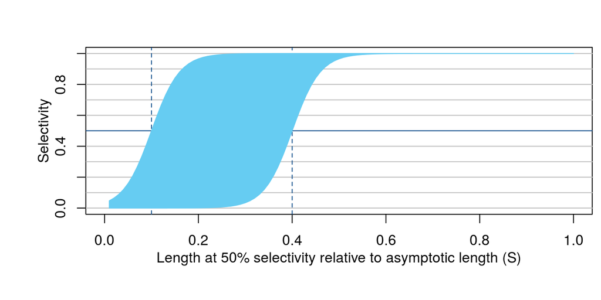

## 3.10 Selectivity of large fish

| Answered |
| --- |
| Asymptotic selectivity (SL = 1) |
| Declining selectivity with length (0.75 < SL < 1) |
| Dome-shaped selectivity (0.25 < SL < 0.75) |
| Strong dome-shaped selectivity (SL < 0.25) |

[output not shown]

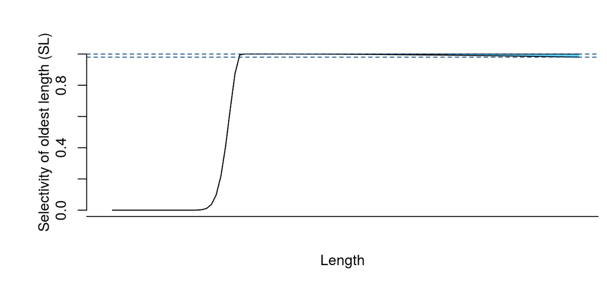

## 3.11 Discard rate

| Answered |
| --- |
| Low (DR < 1%) |
| Low - moderate (1% < DR < 10%) |
| Moderate (10% < DR < 30%) |
| Moderate - high (30% < DR < 50%) |
| High (50% < DR < 70%) |

| Justification |
| --- |
| No information about discarding is provided but it may be low since 1996. |

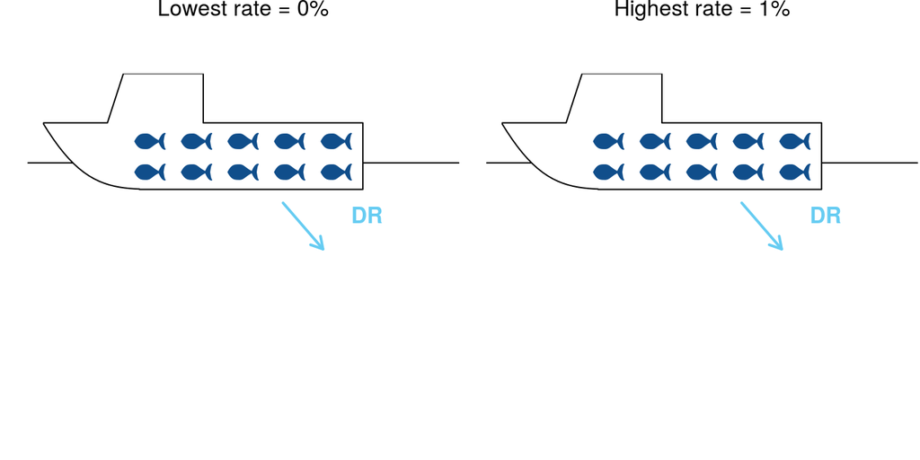

## 3.12 Post-release mortality rate

| Answered |
| --- |
| Low (PRM < 5%) |
| Low - moderate (5% < PRM < 25%) |
| Moderate (25% < PRM < 50%) |
| Moderate - high (50% < PRM < 75%) |
| High (75% < PRM < 95%) |
| Almost all die (95% < PRM < 100%) |

| Justification |
| --- |
| Rockfish no not survive due to barotrauma (COSEWIC 2017, p5) |

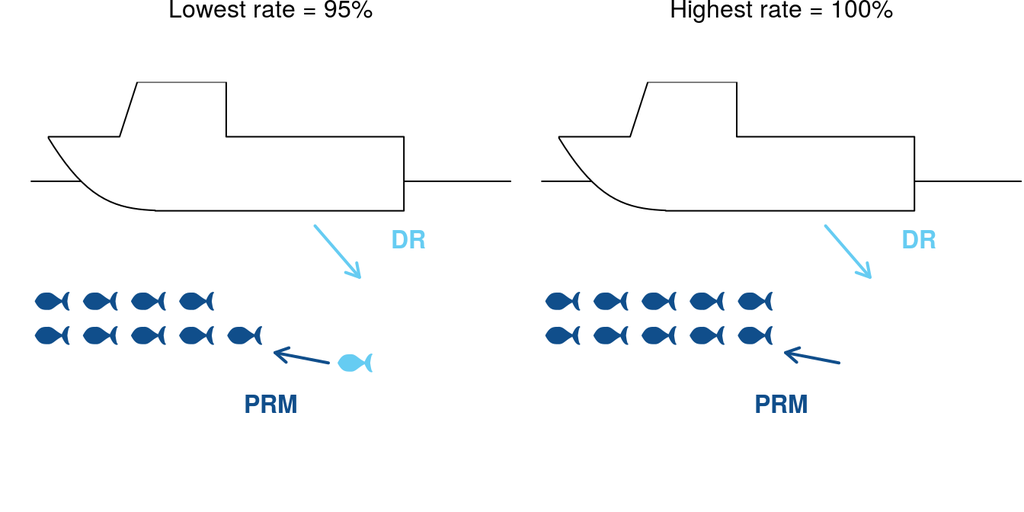

## 3.13 Recruitment variability

| Answered |
| --- |
| Very low (less than 10% inter-annual changes (IAC)) |
| Low (max IAC of between 20% and 60%) |
| Moderate (max IAC of between 60% and 120%) |
| High (max IAC of between 120% and 180%) |
| Very high (max IAC greater than 180%) |

| Justification |
| --- |
| from Table 16 Spencer and Rooper (2016) and 0.814 Shotwell at all (2017) |

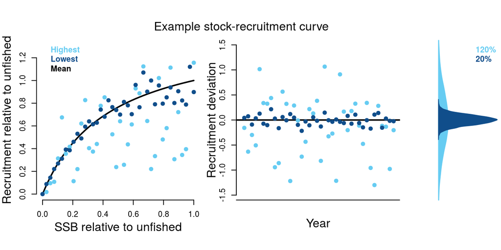

## 3.14 Size of an existing MPA

| Answered |
| --- |
| None |
| Small (A < 5%) |
| Small-moderate (5% < A < 10%) |
| Moderate (10% < A < 20%) |
| Large (20% < A < 30%) |
| Very large (30% < A < 40%) |
| Huge (40% < A < 50%) |

| Justification |
| --- |
| no official habitat protection exist, fishery management control removals of this species is base on coastwide quotas administered by an individual-vessel-quota system (COSEWIC 2017, p13) |

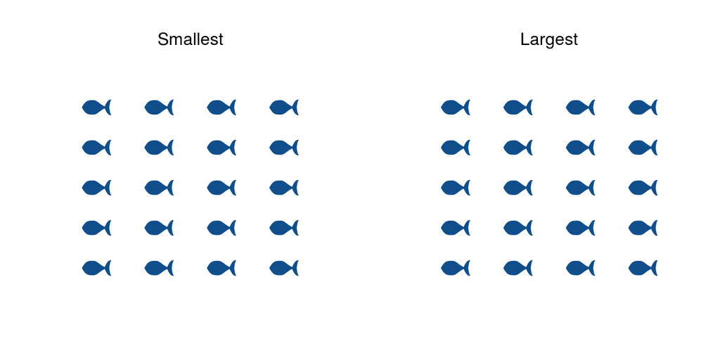

## 3.15 Spatial mixing (movement) in/out of existing MPA

| Answered |
| --- |
| Very low (P < 1%) |
| Low (1% < P < 5%) |
| Moderate (5% < P < 10%) |
| High (10% < P < 20%) |
| Fully mixed |

| Justification |
| --- |
| No justification was provided |

[figure not shown]

## 3.16 Size of a future potential MPA

| Answered |
| --- |
| None |
| Small (A < 5%) |
| Small-moderate (5% < A < 10%) |
| Moderate (10% < A < 20%) |
| Large (20% < A < 30%) |
| Very large (30% < A < 40%) |
| Huge (40% < A < 50%) |

| Justification |
| --- |
| Fishery management control removals of this species is base on coastwide quotas administered by an individual-vessel-quota system (COSEWIC 2017, p13) |

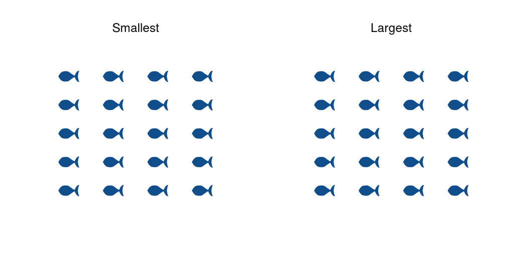

## 3.17 Spatial mixing (movement) in/out of future potential MPA

| Answered |
| --- |
| Very low (P < 1%) |
| Low (1% < P < 5%) |
| Moderate (5% < P < 10%) |
| High (10% < P < 20%) |
| Fully mixed |

| Justification |
| --- |
| No justification was provided |

[figure not shown]

## 3.18 Initial stock depletion

| Answered |
| --- |
| Very low (0.1 < D1 < 0.15) |
| Low (0.15 < D1 < 0.3) |
| Moderate (0.3 < D < 0.5) |
| High (0.5 < D1) |
| Asymptotic unfished levels (D1 = 1) |

[output not shown]

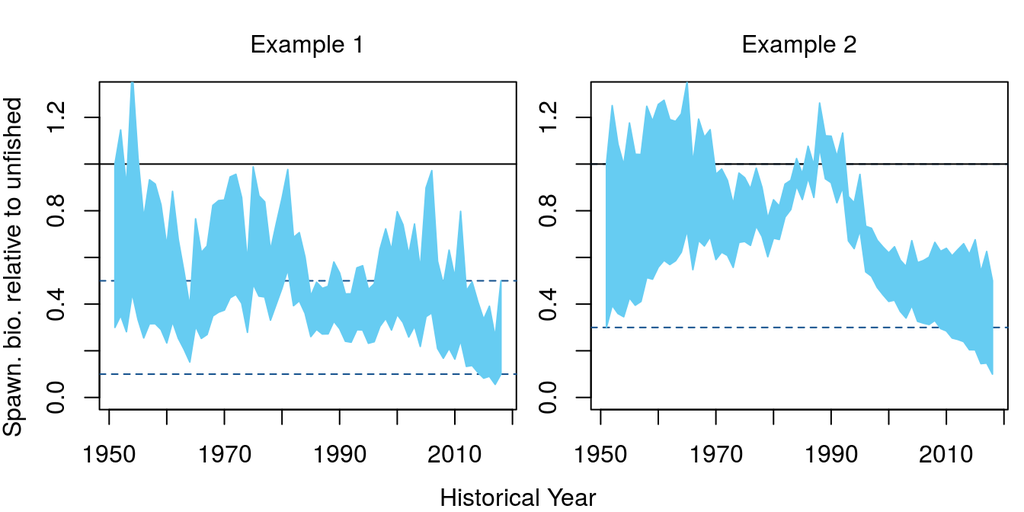

# 4 Management Characteristics

## 4.1 Types of fishery management that are possible

| Answered |
| --- |
| TAC (Total Allowable Catch): a catch limit |
| TAE (Total Allowable Effort): an effort limit |
| Size limit |
| Time-area closures (a marine reserve) |

Justification

1. Describe what, if any, current management measures are used to constrain catch/effort.  
Directed commercial fisheries for the Rougheye/Blackspotted Rockfish complex and Longspine Thornyhead currently exist; with some historical Rougheye/Blackspotted Rockfish complex commercial fishery records dating back to the 1970s (see Section 1.8).  
This fishery is managed by Total Allowable Catches (TACs), Individual Vessel Quotas (IVQs), as well as 100% at-sea and dockside monitoring programs. These TACs are changed over time as new peer-reviewed science information becomes available. The coastwide TAC is currently 1,140 tonnes for the Rougheye/Blackspotted Rockfish complex and 425 tonnes for Longspine Thornyhead.  
It is a complex of species Rougheye/Blackspotted Rockfish. Catches are not separated by species. Thus, this management plan will refer to the sympatric species pair as the ‘Rougheye/Blackspotted Rockfish complex (Fisheries and Oceans Canada. 2012.)  
2. Describe historical management measures, if any.  
3. Describe main strengths and weaknesses of current monitoring and enforcement capacity.  
The commercial fishing sector is subject to a comprehensive 100% at-sea and dockside monitoring program. The relative distribution and abundance of these two species in Canadian waters is unknown. In addition, misidentification for these rockfish species can be problematic, as they are morphologically similar to others in their genus. This phenomenon was possibly more prevalent during the beginning years of the observer program (Haigh and Schnute 2003), suggesting that the accuracy of catch data has changed over time. However, once observers and dockside monitors gained experience, species identification is assumed to have stabilized. The current difficulty in distinguishing Blackspotted from Rougheye Rockfish will require genetic resolution. It appears unlikely that separation by visual cues will suffice (Fisheries and Oceans Canada. 2012.).  
Following significant work through the Commercial Groundfish Industry Advisory Committee (CGIAC) and the Commercial Industry Caucus (CIC), a three year pilot was introduced in the commercial groundfish fisheries in 2006. The reforms focus on 100% at-sea monitoring and 100% dockside monitoring, individual vessel accountability for all catch, both retained and released, individual vessel quotas (IVQs) and reallocation of these quotas between vessels and fisheries to cover catch of non-directed species.  
4. Describe and reference any legal/policy requirements for management, monitoring and enforcement.  
a) All rockfish catch must be accounted for  
b) Rockfish catches will be managed according to established rockfish management areas.  
c) Fish harvesters will be individually accountable for their catch.  
d) New monitoring standards will be established and implemented to meet the above three objectives.  
e) Species and stocks of concern will be closely examined and actions such as reduction of TACs, and other catch limits will be considered and implemented to be consistent with the precautionary approach for management.  
In 2006, due to the introduction of ITQs, 100% catch monitoring requirements in the rockfish hook and line fleet, and interests by the Department to establish the Bowie Seamount as a Marine Protected Area (MPA), the directed fishing effort for the Rougheye/Blackspotted Rockfish complex at Bowie ceased. At present, there is an active directed Sablefish fishery that occurs on the offshore seamounts (including Bowie). The Sablefish seamount fishery is monitored through 100% at-sea and dockside monitoring programs, and indirect catches of the Rougheye/Blackspotted Rockfish complex are permitted through monthly vessel limits. From 2007 to 2009, Rougheye/Blackspotted Rockfish complex landings averaged about 8000 pounds per year for all seamounts combined (Adam Keizer, DFO, Halibut and Sablefish coordinator, pers. comm. 2010).  
In 2007, DFO, with support of the groundfish trawl industry, implemented three sponge reef closures with the intent of providing protection for four identified unique glass sponge reef ecosystems. These sponge reef closures are located in the waters (approximately 200 m deep) of the eastern Queen Charlotte Sound and Hecate Strait, and are closed year round to all bottom trawling. It is likely that the dense coverage of sponge reefs provides shelter to the juveniles and young adults of the Rougheye/Blackspotted Rockfish complex.  
Additionally, under Canada’s Oceans Act, DFO has designated two Marine Protected Areas (MPAs) – the Endeavour Hydrothermal Vents and the Bowie Seamount – within the coastal waters of BC.

## 4.2 TAC offset: consistent overages/underages

| Answered |
| --- |
| Large underages (40% - 70% of recommended) |
| Underages (70% - 90% of recommended) |
| Slight underages (90% - 100% of recommended) |
| Taken exactly (95% - 105% of recommended) |
| Slight overages (100% - 110% of recommended) |
| Overages (110% - 150% of recommended) |
| Large overages (150% - 200% of recommended) |

| Justification |
| --- |
| see Table 9. 1986 to 2000 overages (incomplete information). Then underages for the 2001-2005. However, these catches include BOTH species. |

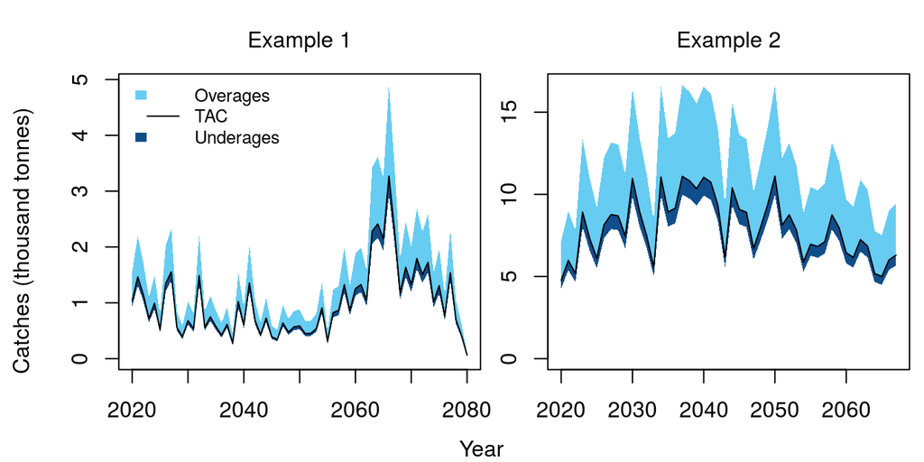

## 4.3 TAC implementation variability

| Answered |
| --- |
| Constant (V < 1%) |
| Not variable (1% < V < 5%) |
| Low variability (5% < V < 10%) |
| Variable (10% < V < 20%) |
| Highly variable (20% < V < 40%) |

| Justification |
| --- |
| No information is provided (TACs) but the CPUE has being stable. |

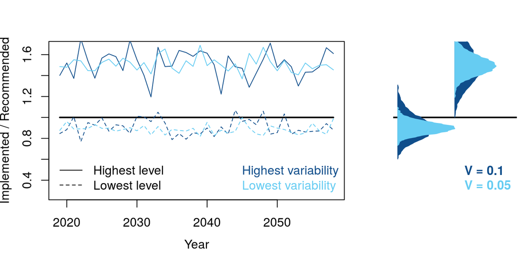

## 4.4 TAE offset: consistent overages/underages

| Answered |
| --- |
| Large underages (40% - 70% of recommended) |
| Underages (70% - 90% of recommended) |
| Slight underages (90% - 100% of recommended) |
| Taken exactly (95% - 105% of recommended) |
| Slight overages (100% - 110% of recommended) |
| Overages (110% - 150% of recommended) |
| Large overages (150% - 200% of recommended) |

| Justification |
| --- |
| No justification was provided |

## 4.5 TAE implementation variability

| Answered |
| --- |
| Constant (V < 1%) |
| Not variable (1% < V < 5%) |
| Low variability (5% < V < 10%) |
| Variable (10% < V < 20%) |
| Highly variable (20% < V < 40%) |

| Justification |
| --- |
| No justification was provided |

[figure not shown]

## 4.6 Size limit offset: consistent overages/underages

| Answered |
| --- |
| Much smaller (40% - 70% of recommended) |
| Smaller (70% - 90% of recommended) |
| Slightly smaller (90% - 100% of recommended) |
| Taken exactly (95% - 105% of recommended) |
| Slightly larger (100% - 110% of recommended) |
| Larger (110% - 150% of recommended) |
| Much larger (150% - 200% of recommended) |

| Justification |
| --- |
| No information is provided in Fisheries and Oceans Canada. 2012 Fisheries and Oceans Canada. 2012 and COSEWIC 2007 must be “Taken exactly” because of the 100% at-sea and dockside monitoring program. |

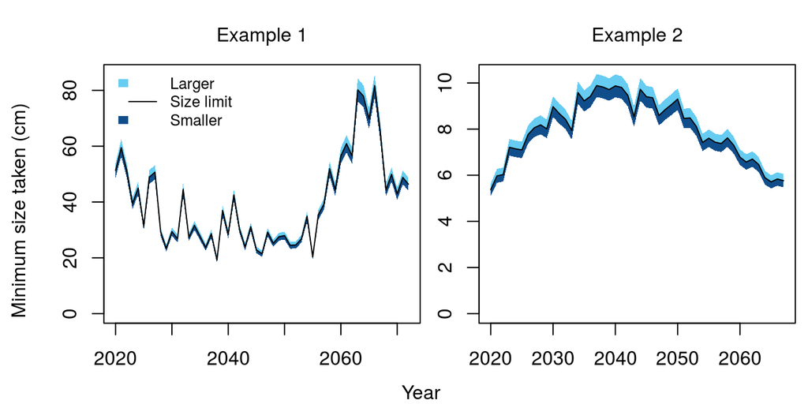

## 4.7 Size limit implementation variability

| Answered |
| --- |
| Constant (V < 1%) |
| Not variable (1% < V < 5%) |
| Low variability (5% < V < 10%) |
| Variable (10% < V < 20%) |
| Highly variable (20% < V < 40%) |

| Justification |
| --- |
| No justification was provided |

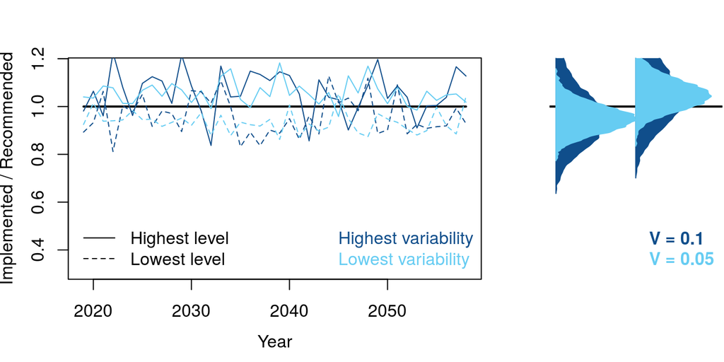

# 5 Data Characteristics

## 5.1 Available data types

| Answered |
| --- |
| Historical annual catches (from unfished) |
| Recent annual catches (at least 5 recent years) |
| Historical relative abundance index (from unfished) |
| Recent relative abundance index (at least 5 recent years) |
| Fishing effort |
| Size composition (length samples) |
| Age composition (age samples) |
| Growth (growth parameters) |
| Absolute biomass survey |

Justification

1. Provide the time series (specify years, if possible) that exist for catch, effort, and CPUE/abundance indices.  
Catches (including discarding) by fleet 1971-2005 (see Table 9 Haigh et al 2005)  
The HS survey index is virtually useless for indexing rougheye rockfish.  
Relative index for rougheye rockfish in Queen Charlotte Sound from the QCS bottom trawl survey (see fig 12, table 15, Haigh et al 2005)  
Relative index for rougheye rockfish in Queen Charlotte Sound from the QCS shrimp trawl survey (see fig 14, table 18, Haigh et al 2005)  
CPUE (Ttable 35, Haigh et al 2005)  
Summary different survey  
2. Describe how these data collected (e.g., log books, dealer reporting, observers).  
see Haigh et al (2005) for details  
3. Describe what types of sampling programs and methodologies exist for data collection, including the time-series of available sampling data and quality.  
see Haigh et al (2005) for details  
4. Describe all sources of uncertainty in the status, biology, life history and data sources of the fishery. Include links to documentation, reports.  
Survey indices of abundance are currently not useful for assessing.  
This fishery includes TWO species (The Rougheye/Blackspotted Rockfish complex). all the current info is not by species. eg life history, catches, and surveys combined for both species. Surveys don’t cover the entire area of distribution. Survey indices of abundance are currently not useful for assessing (Haigh et al (2005).  
rougheye rockfish population trends.  
see Haigh et al (2005) for details

## 5.2 Catch reporting bias

| Answered |
| --- |
| Strong under-reporting (30% - 50%) |
| Under-reporting (10% - 30%) |
| Slight under-reporting (less than 10%) |
| Reported accurately (+/- 5%) |
| Slight over-reporting (less than 10%) |

Justification

Due to the discovery of previously unrecognized species-level variation in what had been considered the Rougheye Rockfish (S. aleutianus), it is acknowledged that historical biological and catch information on the Rougheye Rockfish includes that of the Blackspotted Rockfish (S. melanostictus). Thus, this management plan will refer to the sympatric species pair as the ‘Rougheye/Blackspotted Rockfish complex’ (Haigh et al 2005). So the bias is unknown.

## 5.3 Hyperstability in indices

| Answered |
| --- |
| Strong hyperdepletion (2 < Beta < 3) |
| Hyperdepletion (1.25 < Beta < 2) |
| Proportional (0.8 < Beta < 1.25) |
| Hyperstability (0.5 < Beta < 0.8) |
| Strong hyperstability (0.33 < Beta < 0.5) |

Justification

Due to the discovery of previously unrecognized species-level variation in what had been considered the Rougheye Rockfish (S. aleutianus), it is acknowledged that historical biological and catch information on the Rougheye Rockfish includes that of the Blackspotted Rockfish (S. melanostictus). Thus, this management plan will refer to the sympatric species pair as the ‘Rougheye/Blackspotted Rockfish complex’ (Haigh et al 2005). So the bias is unknown.

| Answered |
| --- |
| Perfect |
| Good (accurate and precise) |
| Data moderate (some what inaccurate and imprecise) |
| Data poor (inaccurate and imprecise) |

[output not shown]

# 6 Version Notes

The package is subject to ongoing testing. If you find a bug or a problem please send a report to t.carruthers@oceans.ubc.ca so that it can be fixed!

shiny-2019-04-30-01:07:19

Open Source, GPL-2 2019